# Reproducible Research Peer Assessment 1

Download ZIP file with data archive, unpack and read CSV.

```r
temp <- tempfile()
download.file("https://d396qusza40orc.cloudfront.net/repdata%2Fdata%2Factivity.zip", method="curl", temp)
activity <- read.csv(unz(temp, "activity.csv"), sep=",",  header = TRUE, stringsAsFactors=FALSE)
unlink(temp)
```

### What is mean total number of steps taken per day?

Aggregate steps by date, and then plot a histogram and calculate the mean and median values of total steps per day:

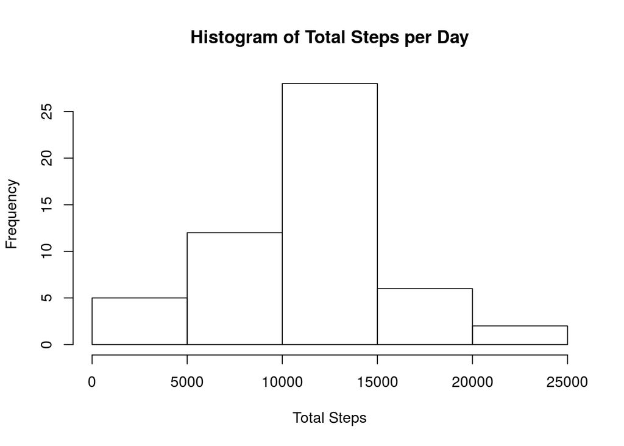

```r
stepsbyday<-aggregate(steps~date, activity, sum)
hist(stepsbyday$steps, breaks=5, main="Histogram of Total Steps per Day", xlab="Total Steps")
```

```r
stmean<-mean(stepsbyday$steps); stmed<-median(stepsbyday$steps)
```

Mean value of the total number of steps taken per day is 10766, while median is 10765

### What is the average daily activity pattern?’

Plot average number of steps taken, averaged across all days, as a time series of a 5-minute intervals:

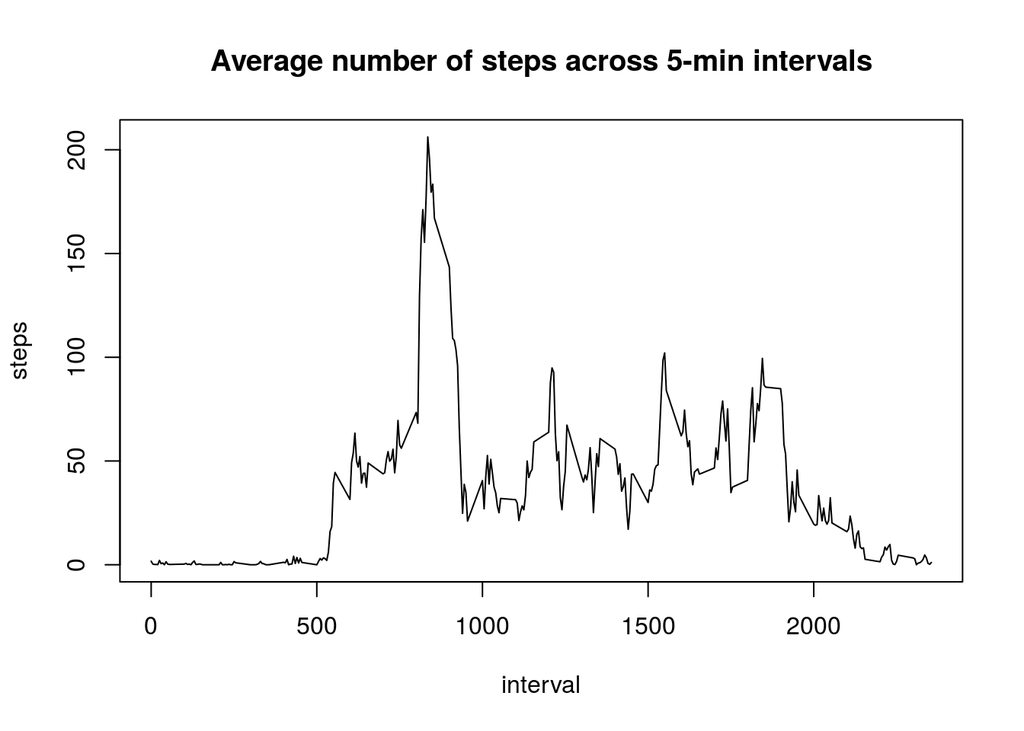

```r
stepsbyint<-aggregate(steps~interval, activity, mean)
plot(stepsbyint, type="l", main="Average number of steps across 5-min intervals")
```

```r
maxint<-stepsbyint[which(stepsbyint$steps==max(stepsbyint$steps)),]$interval
```

Maximum number of steps on average across all the days in the dataset occurs at interval 835.